# *Sentiment Analysis: Are people supportive of Bitcoin?*

# Análisis de sentimiento

El Análisis de Sentimiento es la herramienta de clasificación de texto más común que analiza un mensaje entrante y dice si el sentimiento subyacente es positivo, negativo o neutral. En este caso, es necesario crear la variable target, ya que el dataset elegido no contiene esta variable target.

```python
from nltk.corpus import opinion_lexicon
nltk.download('opinion_lexicon')
```

```
True
```

```python
pip install vaderSentiment
```

```
     |████████████████████████████████| 125 kB 8.6 MB/s
```

```python
from vaderSentiment.vaderSentiment import SentimentIntensityAnalyzer
```

Para hacer el analisis, se utiliza el paquete Vader, el cual utiliza una lista de características léxicas (palabras) que se etiquetan como positivas o negativas según su orientación semántica para calcular el sentimiento del texto. Vader sentiment devuelve la probabilidad de que una frase de entrada sea positiva, negativa o neutra.

```python
def sentiment_scores(df):
    # Create a SentimentIntensityAnalyzer object.
    sid_obj = SentimentIntensityAnalyzer()
    # polarity_scores method of SentimentIntensityAnalyzer
    # oject gives a sentiment dictionary.
    # which contains pos, neg, neu, and compound scores.
    df['sentiment_dict'] = df['cleaned_text'].apply(lambda x: sid_obj.polarity_scores(x))
    df['pcte_negativo'] = df['sentiment_dict'].apply(lambda x: x['neg'])
    df['pcte_neutral'] = df['sentiment_dict'].apply(lambda x: x['neu'])
    df['pcte_postivo'] = df['sentiment_dict'].apply(lambda x: x['pos'])
    # df['pcte_neutral'] = df['sentiment_dict']['neu']
    # df['pcte_positivo'] = df['sentiment_dict']['pos']

    # sentiment_dict = sid_obj.polarity_scores(sentence)
    # print("Overall sentiment dictionary is : ", sentiment_dict)
    # print("sentence was rated as ", sentiment_dict['neg']*100, "% Negative")
    # print("sentence was rated as ", sentiment_dict['neu']*100, "% Neutral")
    # print("sentence was rated as ", sentiment_dict['pos']*100, "% Positive")
    # print("Sentence Overall Rated As", end = " ")
    # decide sentiment as positive, negative and neutral

    df['target'] = np.where((df['sentiment_dict'].apply(lambda x: x['compound'])) >= 0.05, 'Positivo',
                            np.where((df['sentiment_dict'].apply(lambda x: x['compound'])) <= - 0.05, 'Negativo', 'Neutral'))



    return df
```

```python
sentiment_scores(df_cleaned)
```

|  | user_name | user_location | user_description | user_created | user_followers | user_friends | user_favourites | user_verified | date | text | ... | source | is_retweet | non_tokenized_text | tokenized_tweets | cleaned_text | sentiment_dict | pcte_negativo | pcte_neutral | pcte_postivo | target |
| --- | --- | --- | --- | --- | --- | --- | --- | --- | --- | --- | --- | --- | --- | --- | --- | --- | --- | --- | --- | --- | --- |
| 0 | DeSota Wilson | Atlanta, GA | Biz Consultant, real estate, fintech, startups... | 2009-04-26 20:05:09 | 8534.0 | 7605 | 4838 | False | 2021-02-10 23:59:04 | blue ridge bank shares halted nyse bitcoin atm... | ... | Twitter Web App | False | blue ridge bank shares halted nyse bitcoin atm... | [blue, ridge, bank, shares, halted, nyse, bitc... | blue ridge bank shares halted nyse bitcoin atm... | {'neg': 0.0, 'neu': 0.804, 'pos': 0.196, 'comp... | 0.000 | 0.804 | 0.196 | Positivo |
| 1 | CryptoND | NaN | 😎 BITCOINLIVE is a Dutch platform aimed at inf... | 2019-10-17 20:12:10 | 6769.0 | 1532 | 25483 | False | 2021-02-10 23:58:48 | today thursday take 2 friend leowandersleb btc... | ... | Twitter for Android | False | today thursday take 2 friend leowandersleb btc... | [today, thursday, take, 2, friend, leowandersl... | today thursday take 2 friend leowandersleb btc... | {'neg': 0.0, 'neu': 0.588, 'pos': 0.412, 'comp... | 0.000 | 0.588 | 0.412 | Positivo |
| 2 | Tdlmatias | London, England | IM Academy : The best #forex, #SelfEducation, ... | 2014-11-10 10:50:37 | 128.0 | 332 | 924 | False | 2021-02-10 23:54:48 | guys evening read article btc would like share | ... | Twitter Web App | False | guys evening read article btc would like share | [guys, evening, read, article, btc, would, lik... | guys evening read article btc would like share | {'neg': 0.0, 'neu': 0.561, 'pos': 0.439, 'comp... | 0.000 | 0.561 | 0.439 | Positivo |
| 3 | Crypto is the future | NaN | I will post a lot of buying signals for BTC tr... | 2019-09-28 16:48:12 | 625.0 | 129 | 14 | False | 2021-02-10 23:54:33 | btc big chance billion price 4872644 0 2021 02... | ... | dlvr.it | False | btc big chance billion price 4872644 0 2021 02... | [btc, big, chance, billion, price, 4872644, 0,... | btc big chance billion price 4872644 0 2021 02... | {'neg': 0.0, 'neu': 0.882, 'pos': 0.118, 'comp... | 0.000 | 0.882 | 0.118 | Positivo |
| 4 | Alex Kirchmaier 🇦🇹🇸🇪 #FactsSuperspreader | Europa | Co-founder @RENJERJerky \| Forbes 30Under30 \| I... | 2016-02-03 13:15:55 | 1249.0 | 1472 | 10482 | False | 2021-02-10 23:54:06 | network secured 9 508 nodes today soon biggest... | ... | Twitter Web App | False | network secured 9 508 nodes today soon biggest... | [network, secured, 9, 508, nodes, today, soon,... | network secured 9 508 nodes today soon biggest... | {'neg': 0.203, 'neu': 0.64, 'pos': 0.157, 'com... | 0.203 | 0.640 | 0.157 | Negativo |
| ... | ... | ... | ... | ... | ... | ... | ... | ... | ... | ... | ... | ... | ... | ... | ... | ... | ... | ... | ... | ... | ... |
| 995 | Szymon Kostrzewa | NaN | NaN | 2016-04-02 12:33:50 | 7.0 | 75 | 31 | False | 2021-02-10 17:27:33 | follow betfury io let hunt bitcoins together g... | ... | Twitter Web App | False | follow betfury io let hunt bitcoins together g... | [follow, betfury, io, let, hunt, bitcoins, tog... | follow betfury io let hunt bitcoins together g... | {'neg': 0.0, 'neu': 0.802, 'pos': 0.198, 'comp... | 0.000 | 0.802 | 0.198 | Positivo |
| 996 | Crypto Zombie | New York | 🎥 YouTube: Crypto Zombie 🧟‍♂️ #Bitcoin and #bl... | 2010-01-18 23:52:55 | 59416.0 | 1058 | 23385 | False | 2021-02-10 17:27:16 | bitcoin falling tesla pump top btc worried dip... | ... | Twitter Web App | False | bitcoin falling tesla pump top btc worried dip... | [bitcoin, falling, tesla, pump, top, btc, worr... | bitcoin falling tesla pump top btc worried dip... | {'neg': 0.302, 'neu': 0.556, 'pos': 0.143, 'co... | 0.302 | 0.556 | 0.143 | Negativo |
| 997 | Brian Harrington | Anaheim, CA | #Bitcoin is actively replacing the dollar. Can... | 2009-08-19 20:21:01 | 7687.0 | 2322 | 83966 | False | 2021-02-10 17:27:13 | within driving distance iowa city ia definitel... | ... | Twitter Web App | False | within driving distance iowa city ia definitel... | [within, driving, distance, iowa, city, ia, de... | within driving distance iowa city ia definitel... | {'neg': 0.0, 'neu': 0.816, 'pos': 0.184, 'comp... | 0.000 | 0.816 | 0.184 | Positivo |
| 998 | 🔸️Bitcoin Pixel🔸️ | NaN | I discovered crypto in 2019 on Youtube. Since ... | 2015-07-08 13:44:42 | 1873.0 | 75 | 676 | False | 2021-02-10 17:27:10 | question please finally sold avax amp cake bou... | ... | Twitter for Android | False | question please finally sold avax amp cake bou... | [question, please, finally, sold, avax, amp, c... | question please finally sold avax amp cake bou... | {'neg': 0.0, 'neu': 0.881, 'pos': 0.119, 'comp... | 0.000 | 0.881 | 0.119 | Positivo |
| 999 | Crypto is the future | NaN | I will post a lot of buying signals for BTC tr... | 2019-09-28 16:48:12 | 625.0 | 129 | 14 | False | 2021-02-10 17:27:01 | btc going signal 30 minute chart price 4856019... | ... | dlvr.it | False | btc going signal 30 minute chart price 4856019... | [btc, going, signal, 30, minute, chart, price,... | btc going signal 30 minute chart price 4856019... | {'neg': 0.0, 'neu': 1.0, 'pos': 0.0, 'compound... | 0.000 | 1.000 | 0.000 | Neutral |

1000 rows × 21 columns

```python
df_cleaned.groupby('target', dropna=False).count()
```

| target | user_name | user_location | user_description | user_created | user_followers | user_friends | user_favourites | user_verified | date | text | hashtags | source | is_retweet | non_tokenized_text | tokenized_tweets | cleaned_text | sentiment_dict | pcte_negativo | pcte_neutral | pcte_postivo |
| --- | --- | --- | --- | --- | --- | --- | --- | --- | --- | --- | --- | --- | --- | --- | --- | --- | --- | --- | --- | --- |
| Negativo | 102 | 51 | 100 | 102 | 102 | 102 | 102 | 102 | 102 | 102 | 85 | 102 | 102 | 102 | 102 | 102 | 102 | 102 | 102 | 102 |
| Neutral | 478 | 272 | 460 | 478 | 478 | 478 | 478 | 478 | 478 | 478 | 379 | 471 | 478 | 478 | 478 | 478 | 478 | 478 | 478 | 478 |
| Positivo | 420 | 264 | 401 | 420 | 420 | 420 | 420 | 420 | 420 | 420 | 341 | 416 | 420 | 420 | 420 | 420 | 420 | 420 | 420 | 420 |

En la siguiente figura, podemos ver una representación de las frequencias de las 3 clases. Como era de esperar, el sentimiento negativo es el menos común, y la frequencia de un twit neutral y positivo es muy parecida.

También es lógico que la mayoría de twits tengan un label neutral, ya que puede haber mucho contenido informacional (neutral).

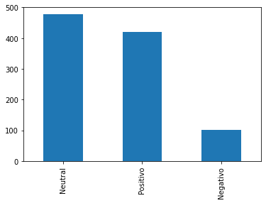

```python
df_cleaned['target'].value_counts().plot(kind="bar")
```

```python
# add number of characters column
df_cleaned["n_chars"] = df_cleaned["cleaned_text"].apply(lambda x: len(x))

# add number of words column
df_cleaned["n_words"] = df_cleaned["cleaned_text"].apply(lambda x: len(x))
```

```python
# create doc2vec vector columns
from gensim.test.utils import common_texts
from gensim.models.doc2vec import Doc2Vec, TaggedDocument

documents = [TaggedDocument(doc, [i]) for i, doc in enumerate(df_cleaned["cleaned_text"].apply(lambda x: x.split(" ")))]

# train a Doc2Vec model with our text data
model = Doc2Vec(documents, vector_size=5, window=2, min_count=1, workers=4)

# transform each document into a vector data
doc2vec_df = df_cleaned["cleaned_text"].apply(lambda x: model.infer_vector(x.split(" "))).apply(pd.Series)
doc2vec_df.columns = ["doc2vec_vector_" + str(x) for x in doc2vec_df.columns]
reviews_df = pd.concat([df_cleaned, doc2vec_df], axis=1)
```

```python
# add tf-idfs columns
from sklearn.feature_extraction.text import TfidfVectorizer
tfidf = TfidfVectorizer(min_df = 10)
tfidf_result = tfidf.fit_transform(df_cleaned["cleaned_text"]).toarray()
tfidf_df = pd.DataFrame(tfidf_result, columns = tfidf.get_feature_names())
tfidf_df.columns = ["word_" + str(x) for x in tfidf_df.columns]
tfidf_df.index = df_cleaned.index
df_cleaned = pd.concat([df_cleaned, tfidf_df], axis=1)
```

```python
df_cleaned.head()
```

|  | user_name | user_location | user_description | user_created | user_followers | user_friends | user_favourites | user_verified | date | text | ... | word_via | word_volume | word_voyager | word_wallet | word_way | word_wi | word_world | word_would | word_xrp | word_year |
| --- | --- | --- | --- | --- | --- | --- | --- | --- | --- | --- | --- | --- | --- | --- | --- | --- | --- | --- | --- | --- | --- |
| 0 | DeSota Wilson | Atlanta, GA | Biz Consultant, real estate, fintech, startups... | 2009-04-26 20:05:09 | 8534.0 | 7605 | 4838 | False | 2021-02-10 23:59:04 | blue ridge bank shares halted nyse bitcoin atm... | ... | 0.0 | 0.0 | 0.0 | 0.000000 | 0.0 | 0.0 | 0.0 | 0.000000 | 0.0 | 0.0 |
| 1 | CryptoND | NaN | 😎 BITCOINLIVE is a Dutch platform aimed at inf... | 2019-10-17 20:12:10 | 6769.0 | 1532 | 25483 | False | 2021-02-10 23:58:48 | today thursday take 2 friend leowandersleb btc... | ... | 0.0 | 0.0 | 0.0 | 0.710778 | 0.0 | 0.0 | 0.0 | 0.000000 | 0.0 | 0.0 |
| 2 | Tdlmatias | London, England | IM Academy : The best #forex, #SelfEducation, ... | 2014-11-10 10:50:37 | 128.0 | 332 | 924 | False | 2021-02-10 23:54:48 | guys evening read article btc would like share | ... | 0.0 | 0.0 | 0.0 | 0.000000 | 0.0 | 0.0 | 0.0 | 0.598643 | 0.0 | 0.0 |
| 3 | Crypto is the future | NaN | I will post a lot of buying signals for BTC tr... | 2019-09-28 16:48:12 | 625.0 | 129 | 14 | False | 2021-02-10 23:54:33 | btc big chance billion price 4872644 0 2021 02... | ... | 0.0 | 0.0 | 0.0 | 0.000000 | 0.0 | 0.0 | 0.0 | 0.000000 | 0.0 | 0.0 |
| 4 | Alex Kirchmaier 🇦🇹🇸🇪 #FactsSuperspreader | Europa | Co-founder @RENJERJerky \| Forbes 30Under30 \| I... | 2016-02-03 13:15:55 | 1249.0 | 1472 | 10482 | False | 2021-02-10 23:54:06 | network secured 9 508 nodes today soon biggest... | ... | 0.0 | 0.0 | 0.0 | 0.000000 | 0.0 | 0.0 | 0.0 | 0.000000 | 0.0 | 0.0 |

5 rows × 207 columns

Una vez se tiene el dataframe final, se procede a crear una sopa de repetición de palabras, y un modelo de clasificación multiclase para poder agrupar los siguientes twits que vengan.

## Sopa de reptición de palabras

Usamos una sopa de repetición de palabras para representar datos textuales en los que el tamaño de cada palabra indica su frecuencia o importancia. Las nubes de palabras se utilizan mucho para analizar datos de sitios web de redes sociales, como en este ejemplo, para analizar el sentimiento del público hacia el Bitcoin.

```python
#word cloud for positive review words
from wordcloud import WordCloud
import matplotlib.pyplot as plt

def show_wordcloud(data, title = None):
    wordcloud = WordCloud(
        background_color = 'white',
        max_words = 200,
        max_font_size = 40,
        scale = 3,
        random_state = 42
    ).generate(str(data))

    fig = plt.figure(1, figsize = (20, 20))
    plt.axis('off')
    if title:
        fig.suptitle(title, fontsize = 20)
        fig.subplots_adjust(top = 2.3)

    plt.imshow(wordcloud)
    plt.show()
```

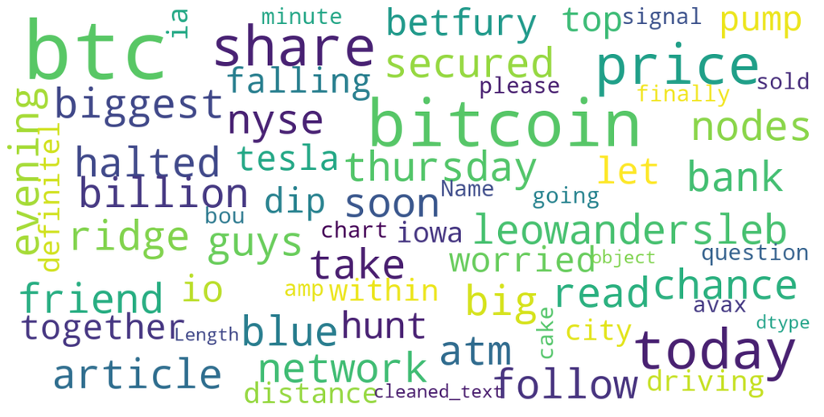

```python
# print wordcloud
show_wordcloud(df_cleaned["cleaned_text"])
```

```python
# highest positive sentiment reviews (with more than 5 words)
df_cleaned[df_cleaned["n_words"] >= 5].sort_values("pcte_postivo", ascending = False)[["cleaned_text", "pcte_postivo"]].head(10)
```

|  | cleaned_text | pcte_postivo |
| --- | --- | --- |
| 950 | love btc bitcoin | 0.677 |
| 363 | 3 reasons love bidcoin fun way get crypto save... | 0.672 |
| 239 | love place able share talents world immersive ... | 0.652 |
| 99 | ftm looking super amazing easily 400 bitcoin b... | 0.627 |
| 90 | great watch simon always great pleasure valuab... | 0.625 |
| 92 | simondixontwitt youtube tesla elonmusk great w... | 0.625 |
| 134 | coinbasesupport please reply dms 4 emails than... | 0.602 |
| 937 | know fun getting rich investment telling peopl... | 0.593 |
| 525 | cashapp dear friend jack knows far bitcoin btc... | 0.585 |
| 724 | generous bitcoin relative pay interest btc axn... | 0.576 |

```python
# highest negative sentiment reviews (with more than 5 words)
df_cleaned[df_cleaned["n_words"] >= 5].sort_values("pcte_negativo", ascending = False)[["cleaned_text", "pcte_negativo"]].head(10)
```

|  | cleaned_text | pcte_negativo |
| --- | --- | --- |
| 868 | freaking slimos needs stop bitcoin btc manipul... | 0.643 |
| 853 | get another drop market wrong bots configured ... | 0.575 |
| 663 | buying btc sucker funneled investing something... | 0.496 |
| 521 | fuck getting near top arent hahaha bitcoin btc | 0.486 |
| 260 | fiona365andmore maxkeiser ecb immoral thievery... | 0.482 |
| 320 | fast furious bitcoin btc tesla payments | 0.425 |
| 125 | ethereum killers layer 2 tokens rally despite ... | 0.416 |
| 614 | take risks lose chance btc bitcoin millionaire... | 0.407 |
| 24 | writing wall ignoring bitcoin btc | 0.403 |
| 313 | shocking btc bitcoin energy | 0.397 |

En este paso, comprabamos que el modelo está funcionando correctamente, y que los twits positivos están categorizados como positivos, y vice versa. Debido a que no se tenía la variable target (twit positivo, negativo o neutral), no podemos comprobar la precisión del modelo.

## Modelo

En el siguiente paso, se procede a crear un modelo para predicir el sentimiento de un twit sobre bitcoin.

Random forest funciona con la unión de muchos árboles de decisión, distintos entre sí, y luego se unen los resultados finales, y por ‘votación’ se decide una decisión final a partir de todos los resultados obtenidos. Se consigue una estimación que tiene menos error sin sobre entrenar el conjunto de datos. Se ha escogido utilizar un RandomForest en lugar de un algoritmo de aprendizaje profundo debido a las limitaciones computacionales. El conjunto de datos que hemos elegido contiene millones de tuits, y, además, las redes neuronales tardan mucho más en entrenarse en comparación con un RandomForest, debido a la naturaleza compleja del aprendizaje profundo, por lo que, a menos que tengamos unas capacidades computacionales extraordinarias, debemos utilizar un RandomForest.

Se dividen los datos para entrenar, un 80%, y el 20% restante se utiliza para validar el modelo. Si se entrenase con todos los datos, sería muy fácil sobre entrenar el modelo.

```python
no_numeric_cols = [
  'user_name',
  'user_location',
  'user_description',
  'user_followers',
  'user_created',
  'user_friends',
  'user_favourites',
  'user_verified',
  'date',
  'text',
  'hashtags',
  'source',
  'is_retweet',
  'tokenized_tweets',
  'sentiment_dict'
]
```

```python
# feature selection: eliminamos las columnas que no representan valor para predecir variable, como user, text etc...
no_prediction_vars = ['target' , *no_numeric_cols]
features = [c for c in df_cleaned.columns if c not in no_prediction_vars]
del features[:2]
```

```python
features
```

```python
# split the data into train and test
from sklearn.ensemble import RandomForestClassifier
from sklearn.model_selection import train_test_split

X_train, X_test, y_train, y_test = train_test_split(df_cleaned[features], df_cleaned['target'], test_size = 0.20, random_state = 42)
```

```python
X_train
```

[output not shown]

800 rows × 190 columns

```python
# entrenamiento de un modelo sencillo para feature importance
# train a random forest classifier
rf = RandomForestClassifier(n_estimators = 100, random_state = 42)
rf.fit(X_train, y_train)
```

```
RandomForestClassifier(random_state=42)
```

La importancia de variables asigna la puntuación de las características de entrada en función de su importancia para predecir el resultado. Cuanto más importantes sean las características para predecir el resultado, mayor será su puntuación.

Como era de esperar, las variables mas importantes para clasificar el sentimiento de un twit son, el porcentage del twit que es neutral, positivo o negativo. Con estas tres variables, somos capaces de clasificar los twits con una precisión muy alta.

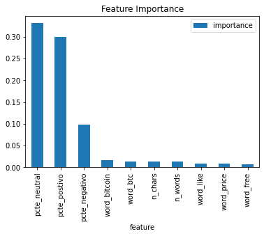

```python
# show feature importance
import matplotlib.pyplot as plt
feature_importances_df = pd.DataFrame({"feature": features, "importance": rf.feature_importances_}).sort_values("importance", ascending = False)
top_10 = feature_importances_df.head(10)
top_10.plot(x ='feature', y='importance', kind = 'bar', title = 'Feature Importance')
```

```python
# Predicting the Test set results
y_pred = rf.predict(X_test)
```

```python
import numpy as np

import seaborn as sns

def make_confusion_matrix(cf,
                          group_names=None,
                          categories='auto',
                          count=True,
                          percent=True,
                          cbar=True,
                          xyticks=True,
                          xyplotlabels=True,
                          sum_stats=True,
                          figsize=None,
                          cmap='Blues',
                          title='Confusion matrix for tweets classification'):
    '''
    This function will make a pretty plot of an sklearn Confusion Matrix cm using a Seaborn heatmap visualization.
    Arguments
    ---------
    cf:            confusion matrix to be passed in
    group_names:   List of strings that represent the labels row by row to be shown in each square.
    categories:    List of strings containing the categories to be displayed on the x,y axis. Default is 'auto'
    count:         If True, show the raw number in the confusion matrix. Default is True.
    normalize:     If True, show the proportions for each category. Default is True.
    cbar:          If True, show the color bar. The cbar values are based off the values in the confusion matrix.
                   Default is True.
    xyticks:       If True, show x and y ticks. Default is True.
    xyplotlabels:  If True, show 'True Label' and 'Predicted Label' on the figure. Default is True.
    sum_stats:     If True, display summary statistics below the figure. Default is True.
    figsize:       Tuple representing the figure size. Default will be the matplotlib rcParams value.
    cmap:          Colormap of the values displayed from matplotlib.pyplot.cm. Default is 'Blues'
                   See http://matplotlib.org/examples/color/colormaps_reference.html

    title:         Title for the heatmap. Default is None.
    '''


    # CODE TO GENERATE TEXT INSIDE EACH SQUARE
    blanks = ['' for i in range(cf.size)]

    if group_names and len(group_names)==cf.size:
        group_labels = ["{}\n".format(value) for value in group_names]
    else:
        group_labels = blanks

    if count:
        group_counts = ["{0:0.0f}\n".format(value) for value in cf.flatten()]
    else:
        group_counts = blanks

    if percent:
        group_percentages = ["{0:.2%}".format(value) for value in cf.flatten()/np.sum(cf)]
    else:
        group_percentages = blanks

    box_labels = [f"{v1}{v2}{v3}".strip() for v1, v2, v3 in zip(group_labels,group_counts,group_percentages)]
    box_labels = np.asarray(box_labels).reshape(cf.shape[0],cf.shape[1])


    # CODE TO GENERATE SUMMARY STATISTICS & TEXT FOR SUMMARY STATS
    if sum_stats:
        #Accuracy is sum of diagonal divided by total observations
        accuracy  = np.trace(cf) / float(np.sum(cf))

        #if it is a binary confusion matrix, show some more stats
        if len(cf)==2:
            #Metrics for Binary Confusion Matrices
            precision = cf[1,1] / sum(cf[:,1])
            recall    = cf[1,1] / sum(cf[1,:])
            f1_score  = 2*precision*recall / (precision + recall)
            stats_text = "\n\nAccuracy={:0.3f}\nPrecision={:0.3f}\nRecall={:0.3f}\nF1 Score={:0.3f}".format(
                accuracy,precision,recall,f1_score)
        else:
            stats_text = "\n\nAccuracy={:0.3f}".format(accuracy)
    else:
        stats_text = ""


    # SET FIGURE PARAMETERS ACCORDING TO OTHER ARGUMENTS
    if figsize==None:
        #Get default figure size if not set
        figsize = plt.rcParams.get('figure.figsize')

    if xyticks==False:
        #Do not show categories if xyticks is False
        categories=False


    # MAKE THE HEATMAP VISUALIZATION
    plt.figure(figsize=figsize)
    sns.heatmap(cf,annot=box_labels,fmt="",cmap=cmap,cbar=cbar,xticklabels=categories,yticklabels=categories)

    if xyplotlabels:
        plt.ylabel('True label')
        plt.xlabel('Predicted label' + stats_text)
    else:
        plt.xlabel(stats_text)

    if title:
        plt.title(title)
```

```python
from sklearn.metrics import confusion_matrix, cohen_kappa_score
```

```python
cf_matrix = confusion_matrix(y_test, y_pred, labels=None, sample_weight=None, normalize=None)
```

```python
kappa = cohen_kappa_score(y_test, y_pred, labels=None, weights=None, sample_weight=None)
kappa
```

```
0.9485398173163515
```

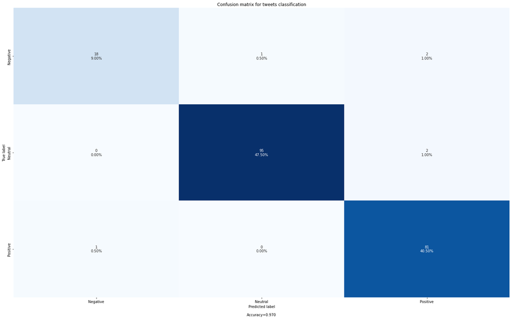

```python
labels = ['True Neg','False Pos','False Neg','True Pos']
categories = ['Negative', 'Neutral', 'Positive']
make_confusion_matrix(
    cf_matrix,
    group_names=labels,
    categories=categories,
    figsize=(25,15),
    cbar=False)
```

Como se puede observar, el modelo obtiene una precisión del 97%, extremadamente alta teniendo en cuenta de que es un problema de clasificación multiclase.

También podemos observar como el coeficiente de Cohen es del 94%, algo mas bajo que las precisión. Esto se debe a que en lugar de calcular el porcentaje de elementos en los que coinciden los evaluadores, el coeficiente de Cohen tiene en cuenta de que se puede acertar la clase aleatoriamente, por lo tanto siempre va a ser menor que la precisión. Aún asi, este valor sigue siendo muy positivo, indicando que nuestro modelo esta funcionando como se esperaba.

La idea principal para llevar a cabo este proyecto es poder utilizarlo como un punto de información extra cuando se va a invertir en un activo. En este caso específico, se han utilzado twits de bitcoin, pero se podría hacer para cualquier tipo de activo.

Sería interesante probar una estrategia de inversión en la cual se compre el activo cuando el sentimiento general del activo sea positivo, y vender la posición cuando el sentimiento sea negativo.